# A PCA Approach to Hedging UK Pension Liabilities

06/10/2020

## UK DB Pension Market

- 10 Million Members
- 5436 DB Schemes left in UK (7751 in 2006)
- £1.6tr in UK Pension Liabilities
  - 26% Schemes have more than £100m Liabilities
  - 5% Schemes have more than £1bn Liabilities

## DB Pension Scheme Risks

- Interest Rate
- Inflation
- Longevity

## History of Pension Fund Hedging

- Pre - 2000: Immunization:(Matched Duration, Asset Convexity > Liability Convexity)
  - ignores cost of convexity
  - assumes parallel curve moves
- 2000 - 2020: PV01, IE01 buckets across curve
  - ignores intra bucket volatility
  - hedge is more complex

## Current Approaches

- Using the whole curve to discount liabilities
  - Spurious accuracy
- Picking representative points on the curve
  - Choice of points is arbitrary
- Liability Benchmark Portfolio (LBP)
  - Convexity mismatch
  - Credit spreads

## PCA Approach

- Assume that linear factor structure exists
- Assume factor loadings are stable
- Infer factors from data

## UK Yield Curve

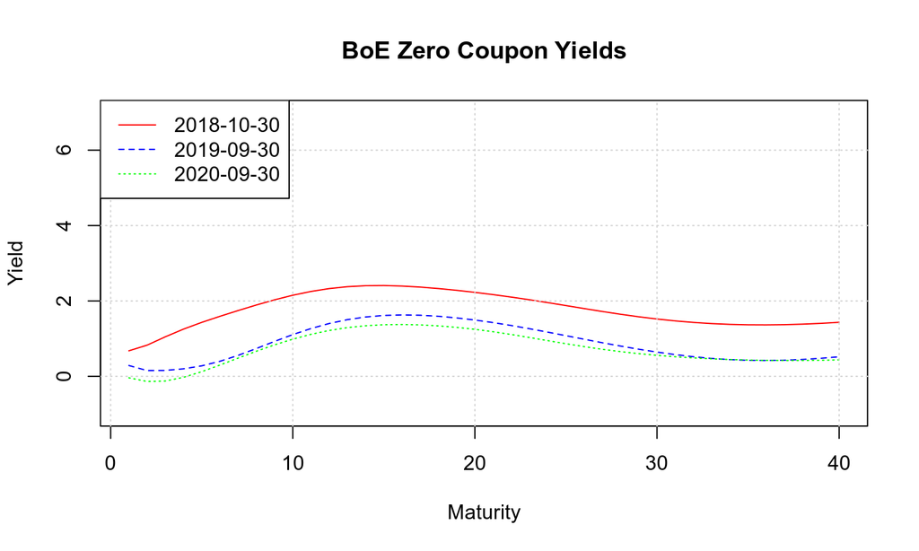

## Yield Correlation

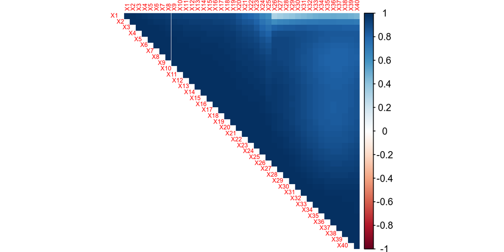

- Darkest on diagonal and lightest in top right corner
- Adjacent maturities should have higher correlations

## Interpretting the PCAs

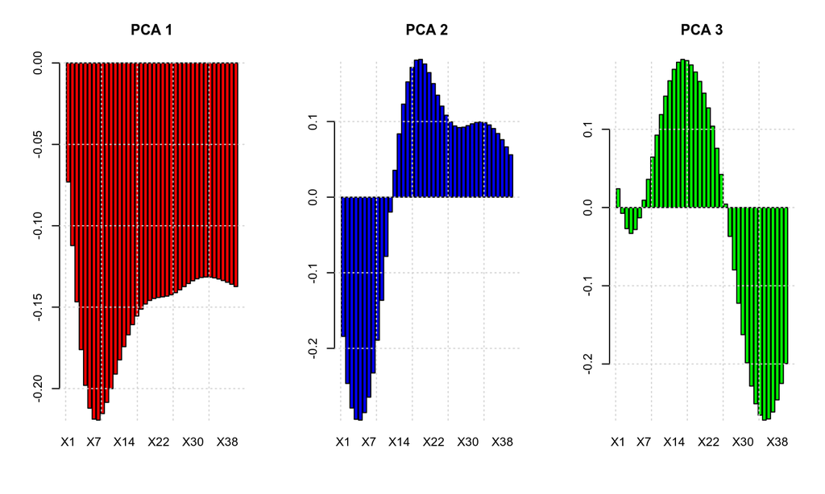

## Principal Component Analysis

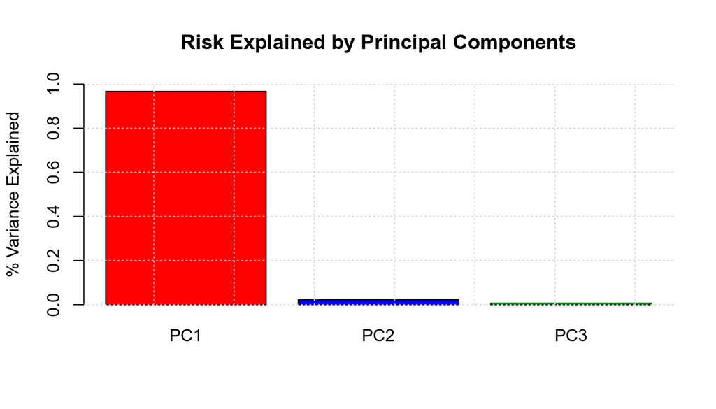

| PCA 1 | PCA 2 | PCA 3 |
| --- | --- | --- |
| 96.69 | 2.25 | 0.68 |

## Typical UK DB Scheme

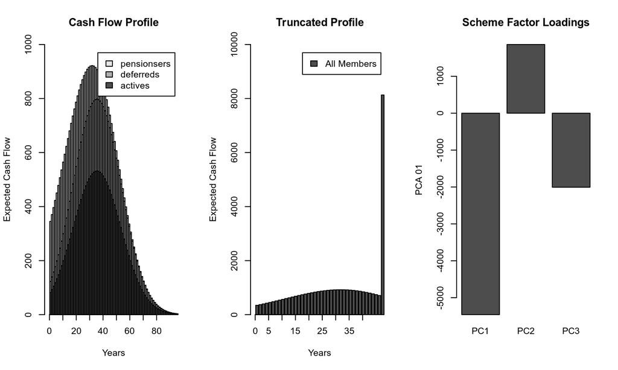

## Building the hedge

- We know the factor loadings of the Scheme
- We know the factor loadings of each point on the yield curve \(\implies\) we know factor loading of each bond/swap
- Back out how much of each bond/swap we need to hedge the Scheme

## How have PCAs behaved

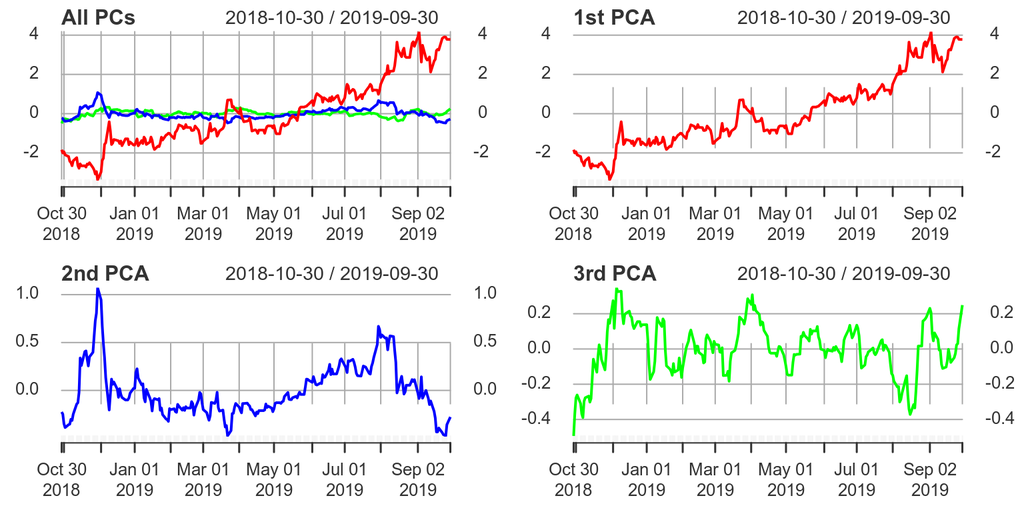

## Trade Ideas

| . | PCA 1 | PCA 2 | PCA 3 |
| --- | --- | --- | --- |
| Value | 3.779 | -0.277 | 0.249 |
| SDs from Mean | 2.1 | -1 | 1.7 |

## Selecting an Asset to trade

- Assume that you want to trade PCA2

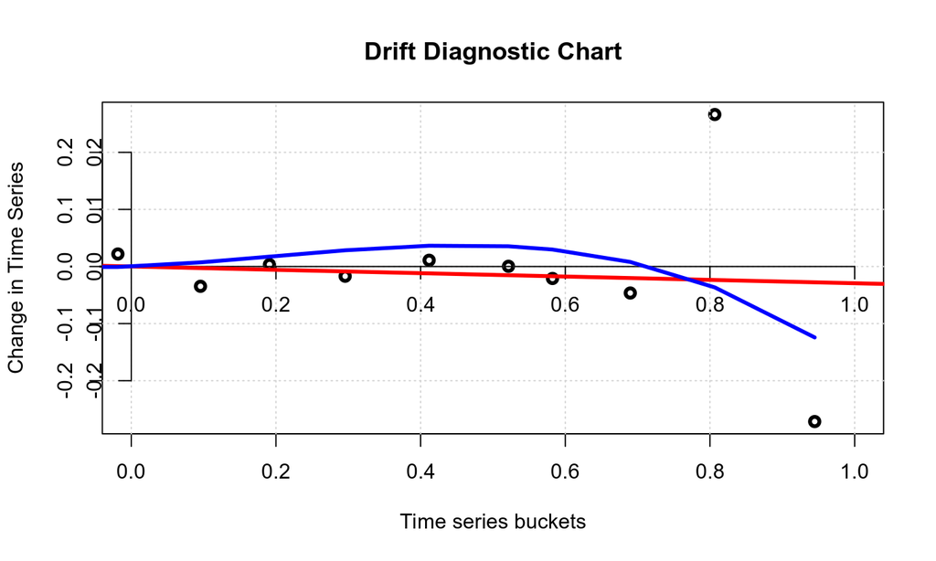

## Forecasting

- Idea 1: Fit Orstein Uhlenbeck (Vasicek) Process
  - Huggins and Schaller approach
  - assumes the only information that is useful in calculating the change is the current value.
  - no trending away from mean
- Idea 2: Fit Auto Regressive model, AR(p)
  - somewhat of a Blackbox
  - allows for trending away from mean
  - need to infer the order p, of the AR model

## AR model

This chart shows the expected path of the PCA 2. The chart below fits an AR model.

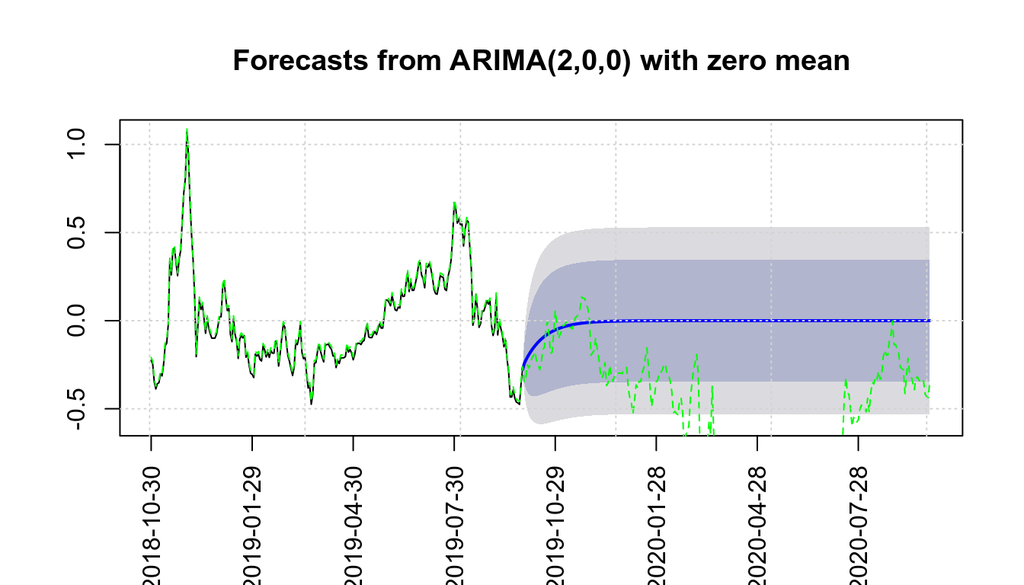

## Vasicek Model

SDE for Vasicek model : \(dr_{t}= \kappa (\theta - r_t) + \sigma dW_t\)

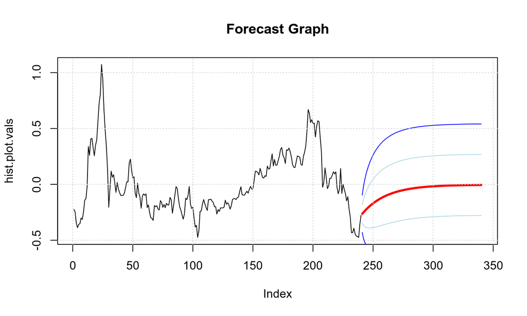

## Conclusions

- Benefits
  - We can simplify the hedge
  - We can identify tactical trading opportunities
  - Challenge trade ideas after execution systematically
- Limitations/Further Research
  - explaining approach to Trustees
  - stability of factor loadings
  - Converting ZC to real bonds

## Dataset

Source: Bank of England daily nominal Zero Coupon Yields estimated using Nelsen Siebold Method. https://www.bankofengland.co.uk/-/media/boe/files/statistics/yield-curves/latest-yield-curve-data.zip